# CMSC/LING/STAT 208: ML - Homework 10

Jo Dang

### This homework assignment is intended as practice with unsupervised learning approaches.

## Question 1

For this question, you will work with the `NCI60` microarray dataset. The data contains expression levels on 6830 genes from 64 cancer cell lines.

```r
library(ISLR2)   # load package

ncidata <- NCI60$data   # load dataset

dim(ncidata)    # dimension of the dataset (number of rows x number of columns)
```

```
## [1]   64 6830
```

### Part I

1. Implement PCA on the standardized (centered and scaled) data. How many PCs are required to explain at least 75% of the overall variance?

```r
# write your R code here
set.seed(10)

pca <- prcomp(ncidata, center = TRUE, scale = TRUE)

summary(pca)
```

```
## Importance of components:
##                            PC1      PC2      PC3      PC4      PC5      PC6
## Standard deviation     27.8535 21.48136 19.82046 17.03256 15.97181 15.72108
## Proportion of Variance  0.1136  0.06756  0.05752  0.04248  0.03735  0.03619
## Cumulative Proportion   0.1136  0.18115  0.23867  0.28115  0.31850  0.35468
##                             PC7      PC8      PC9     PC10     PC11     PC12
## Standard deviation     14.47145 13.54427 13.14400 12.73860 12.68672 12.15769
## Proportion of Variance  0.03066  0.02686  0.02529  0.02376  0.02357  0.02164
## Cumulative Proportion   0.38534  0.41220  0.43750  0.46126  0.48482  0.50646
##                            PC13     PC14     PC15     PC16     PC17     PC18
## Standard deviation     11.83019 11.62554 11.43779 11.00051 10.65666 10.48880
## Proportion of Variance  0.02049  0.01979  0.01915  0.01772  0.01663  0.01611
## Cumulative Proportion   0.52695  0.54674  0.56590  0.58361  0.60024  0.61635
##                            PC19    PC20     PC21    PC22    PC23    PC24
## Standard deviation     10.43518 10.3219 10.14608 10.0544 9.90265 9.64766
## Proportion of Variance  0.01594  0.0156  0.01507  0.0148 0.01436 0.01363
## Cumulative Proportion   0.63229  0.6479  0.66296  0.6778 0.69212 0.70575
##                           PC25    PC26    PC27   PC28    PC29    PC30    PC31
## Standard deviation     9.50764 9.33253 9.27320 9.0900 8.98117 8.75003 8.59962
## Proportion of Variance 0.01324 0.01275 0.01259 0.0121 0.01181 0.01121 0.01083
## Cumulative Proportion  0.71899 0.73174 0.74433 0.7564 0.76824 0.77945 0.79027
##                           PC32    PC33    PC34    PC35    PC36    PC37    PC38
## Standard deviation     8.44738 8.37305 8.21579 8.15731 7.97465 7.90446 7.82127
## Proportion of Variance 0.01045 0.01026 0.00988 0.00974 0.00931 0.00915 0.00896
## Cumulative Proportion  0.80072 0.81099 0.82087 0.83061 0.83992 0.84907 0.85803
##                           PC39    PC40    PC41   PC42    PC43   PC44    PC45
## Standard deviation     7.72156 7.58603 7.45619 7.3444 7.10449 7.0131 6.95839
## Proportion of Variance 0.00873 0.00843 0.00814 0.0079 0.00739 0.0072 0.00709
## Cumulative Proportion  0.86676 0.87518 0.88332 0.8912 0.89861 0.9058 0.91290
##                          PC46    PC47    PC48    PC49    PC50    PC51    PC52
## Standard deviation     6.8663 6.80744 6.64763 6.61607 6.40793 6.21984 6.20326
## Proportion of Variance 0.0069 0.00678 0.00647 0.00641 0.00601 0.00566 0.00563
## Cumulative Proportion  0.9198 0.92659 0.93306 0.93947 0.94548 0.95114 0.95678
##                           PC53    PC54    PC55    PC56    PC57   PC58    PC59
## Standard deviation     6.06706 5.91805 5.91233 5.73539 5.47261 5.2921 5.02117
## Proportion of Variance 0.00539 0.00513 0.00512 0.00482 0.00438 0.0041 0.00369
## Cumulative Proportion  0.96216 0.96729 0.97241 0.97723 0.98161 0.9857 0.98940
##                           PC60    PC61    PC62    PC63      PC64
## Standard deviation     4.68398 4.17567 4.08212 4.04124 1.237e-14
## Proportion of Variance 0.00321 0.00255 0.00244 0.00239 0.000e+00
## Cumulative Proportion  0.99262 0.99517 0.99761 1.00000 1.000e+00
```

```
We need 28 PCs to explain at least 75% of the overall variance.
```

2. Create a scree plot of **all** the PCs obtained. Suggest a suitable number of PCs for this data by examining the scree plot. [See help page of `screeplot` function to specify the number of components to be plotted]

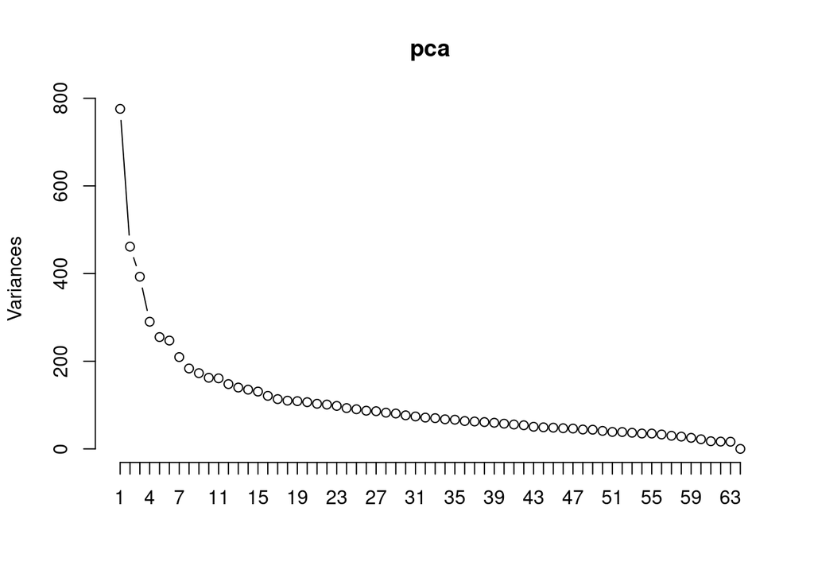

```
From the plot alone, I would suggest either 5 or 8 PCs.
```

```r
# write your R code here
set.seed(10)

screeplot(pca, type = "lines" , npcs = 64)
```

### Part II

Implement K-means clustering on the standardized (centered and scaled) data with $K=4$ and 20 random initial configurations. What are the cluster sizes?

```r
# write your R code here
set.seed(10)

# scale the data set
nci_scaled <- scale(ncidata, center = TRUE, scale = TRUE)

km <- kmeans(nci_scaled, centers = 4, nstart = 20)
km$size
```

```
## [1]  8  9 27 20
```

```
The 4 clusters have sizes 8, 9, 27, 20.
```

### Part III

1. Implement hierarchical clustering on the standardized (centered and scaled) data using complete, single, and average linkages. Comment on how the dendrograms from the different linkage methods compare.

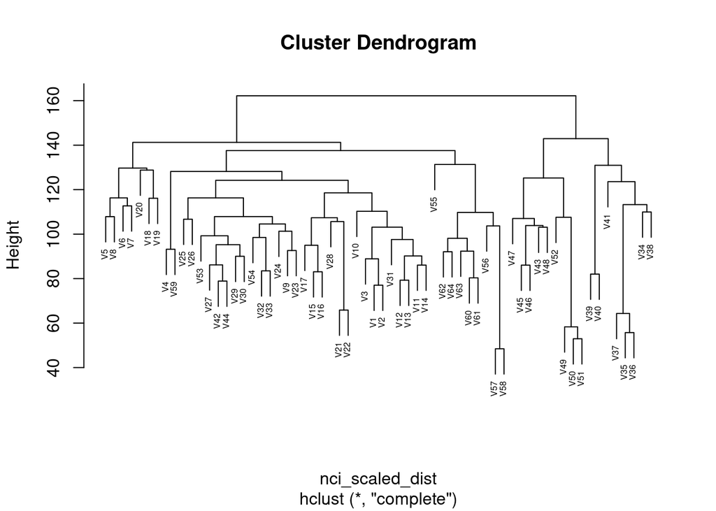

```r
# write your R code here
set.seed(10)

nci_scaled_dist <- dist(nci_scaled, method = "euclidean")   # compute distance matrix

# hierarchical clustering with complete linkage

hclust_complete <- hclust(nci_scaled_dist, method = "complete")

plot(hclust_complete, cex = 0.5)
```

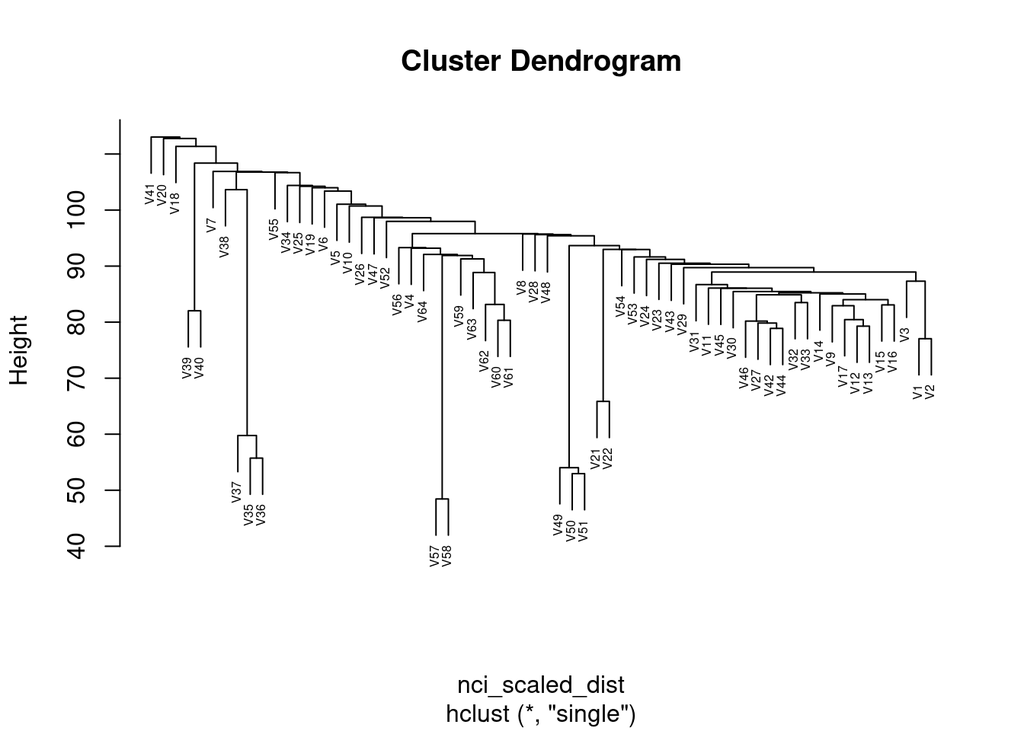

```r
hclust_single <- hclust(nci_scaled_dist, method = "single")

plot(hclust_single, cex = 0.5)
```

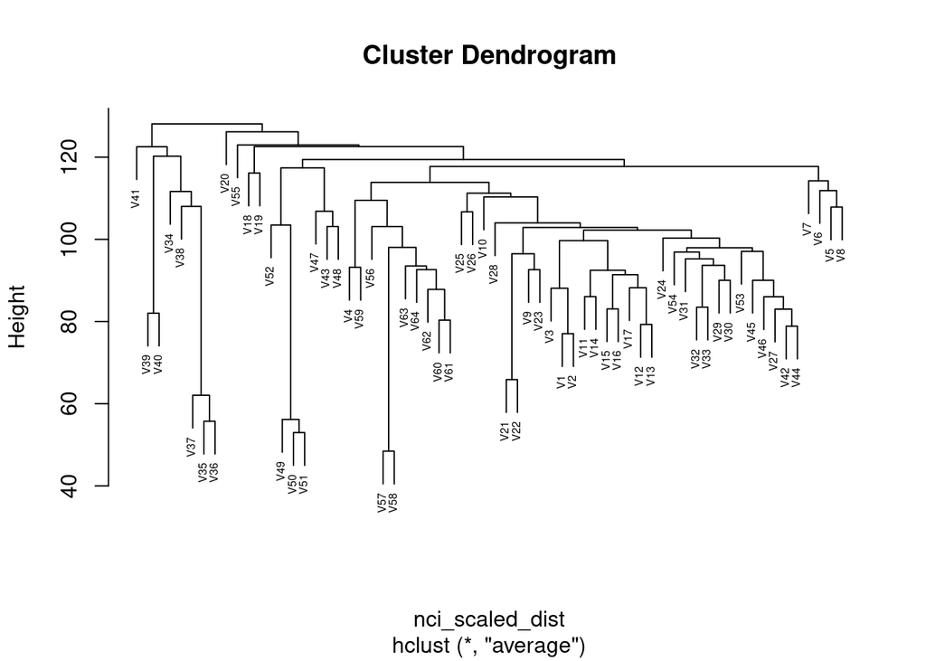

[output not shown]

```r
hclust_average <- hclust(nci_scaled_dist, method = "average")

plot(hclust_average, cex = 0.5)
```

2. Cut the dendrogram built with complete linkage to have 4 clusters. What are the cluster sizes?

```r
# write your R code here
set.seed(10)

ctc <- cutree(hclust_complete, k = 4)   # cut the dendrogram to obtain 4 clusters

table(ctc)   # cluster sizes
```

```
## ctc
##  1  2  3  4
## 40  7  8  9
```

```
The cluster sizes are 40, 7, 8, 9.
```

3. For this data, what are the minimum and maximum number of clusters `k` one can specify in the `cutree` function? What will be the corresponding cluster sizes? Explain.

```
Minimum k: k = 1, cluster size = 64. The minimum k is always 1, because we can't create 0 clusters. k = 1 just means that we are putting all the observations in 1 cluster. So, the size of that cluster would be equal to the number of observations, or 64 in this case.

Maximum k: k = 64, the cluster sizes of each and every cluster is the same and equals 1. The maximum k is n, or the number of observations. In other words, we have n clusters and each of them contain 1 observation. Then, of course, each cluster would have the size of 1.
```

## Question 2

Suppose you have a standardized data matrix $X$ with $n$ observations and $p$ features. What will be the total within-cluster variation (total within-cluster sum of squares) when you implement K-means with $K=n$? What will be the corresponding cluster sizes? Explain your answer.

```
K = n -> there will be n clusters -> there is only 1 observation in each cluster -> there is no variation within each of the clusters -> total within-cluster variation would be 0

The cluster sizes would all be 1, because there is only 1 observation in each cluster.
```